# Week3

Sarfaraz Ahmed

July 7, 2017

# Lab 3: Professional Bull Riding

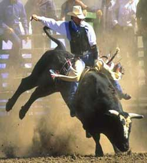

Over 1,200 bull riders from around the world are members of the Professional Bull Riders (PBR). They compete in more than 300 PBR-affiliated bull riding events per year. In the American tradition, the rider must stay atop the bucking bull for a full eight seconds. This data set includes information about the top-ranked bull riders for 2013. Rankings are based on a system which awards points for qualified rides at events throughout the season. More information is available at: http://www.pbr.com/en/bfts/standings/riders.aspx.

Primary Research Question

For the 2013 season, Is there a linear relationship between how often a rider placed in the Top 10 and the number of times he stayed on his bull for a full 8 seconds?

problem 3 points possible (graded) Check the Data

Let’s begin by examining our data in R.

1. Open RStudio. Make sure you’ve installed the current version of the SDSFoundations package.
2. Type library(SDSFoundations). This will automatically load the data for the labs. 3.Type bull <- BullRiders. This will assign the data to your Workspace.
3. Look at the spreadsheet view of the data to answer the following questions.

Alternatively, you can use follow the steps in the “Importing a Data Frame” R tutorial video, and use the BullRiders.csv file. (Right-click and “Save As.”) Make sure to name the dataframe “bull” when importing.

1. Open RStudio.
2. Click on “Import Dataset” button at the top of the workspace window. Choose “from text file.”
3. Click on the location of the BullRiders.csv file you just downloaded.
4. Click on the BullRiders.csv file. Then, click Upload.
5. Look at the spreadsheet view of the data to answer the following questions.

```r
library(SDSFoundations)
bull <- BullRiders

nrow(bull)
```

```
## [1] 58
```

```r
head(bull, 10)
```

```
##                   Rider Rank15 Country YearBorn Height Weight YearsPro
## 1   Joao Ricardo Vieira      1     BRA     1984     66    163        3
## 2         Matt Triplett      2     USA     1991     67    160        4
## 3           J.B. Mauney      3     USA     1987     70    140       10
## 4        Kaique Pacheco      4     BRA     1994     68    145        2
## 5        Nathan Schaper      5     USA     1990     73    160        6
## 6  Valdiron de Oliveira      6     BRA     1979     72    170        9
## 7      Guilherme Marchi      7     BRA     1982     70    180       16
## 8         Silvano Alves      8     BRA     1987     67    150        7
## 9           Reese Cates      9     USA     1989     68    135        9
## 10          J.W. Harris     10     USA     1986     70    160       10
##    Events14 BuckOuts14 Rides14 CupPoints14 Rank14 RidePer14
## 1        28         93      41     9520.25      2    0.4409
## 2        28         86      33     7493.58      3    0.3837
## 3        22         63      25     4973.50      4    0.3968
```

[output cut: 62 more lines]

1a. How many observations are in the dataset? 58 correct 58 1b. How many of the first 10 riders in the dataset have been pro for 10 years or more? 3 correct 3 1c. Of the top 15 riders so far in 2015, how many rides were completed by the rider with the fewest buck-outs in 2014? 0 correct 0

problem 3/4 points (graded) Check the Variables of interest

Let’s find the variables we need to answer the question.

Note: Be sure variable names are exact matches to the dataset. Fill-in-the-blank questions are case sensitive.

2a. Which variable tells us how many times the rider has placed in the Top 10 at the end of the 2013 season? The variable name in the dataset is:

Rank13 incorrectTop10_13 2b. What type of variable is this?

correctNumerical 2c. Which variable tells us the number of times a rider stayed on his bull for the full 8 seconds in 2013? The variable name in the dataset is:

Rides13 correctRides13 2d. What type of variable is this?

correctNumerical

problem 2/2 points (graded) Reflect on the Method

Which method should we be using for the analysis and why?

3. We will use correlation to answer this lab question. Why?

We have two categorical variables that may be related. We want to explore a linear relationship between two quantitative variables. correct We want to determine how a professional bull rider makes it onto the Top 10 list. We want to describe the distribution of a quantitative variable. 4. We should generate a scatterplot of these two variables before we continue our analysis. Why?

We need to check the shape of the distribution. It is a good idea to make sure that we have quantitative data by plotting it. We want to confirm that the relationship is linear. correct We need to identify how many cases are in the dataset.

Primary Research Question

For the 2013 season, Is there a linear relationship between how often a rider places in the Top 10 and the number of times he stayed on his bull for a full 8 seconds?

Breakdown Your Analysis

Let’s break this analysis into its required steps:

1. Create a subset of the data which contains only those riders that have participated in at least one event in 2013.
2. Create a scatterplot of the two variables of interest.
3. Check to see that the relationship is linear. Plot a line of best fit as a guide.
4. If the relationship is linear, calculate the correlation coefficient.
5. Carefully examine any outliers.
6. Interpret what the correlation says about the linear relationship between these variables.

Here is the code you will use:

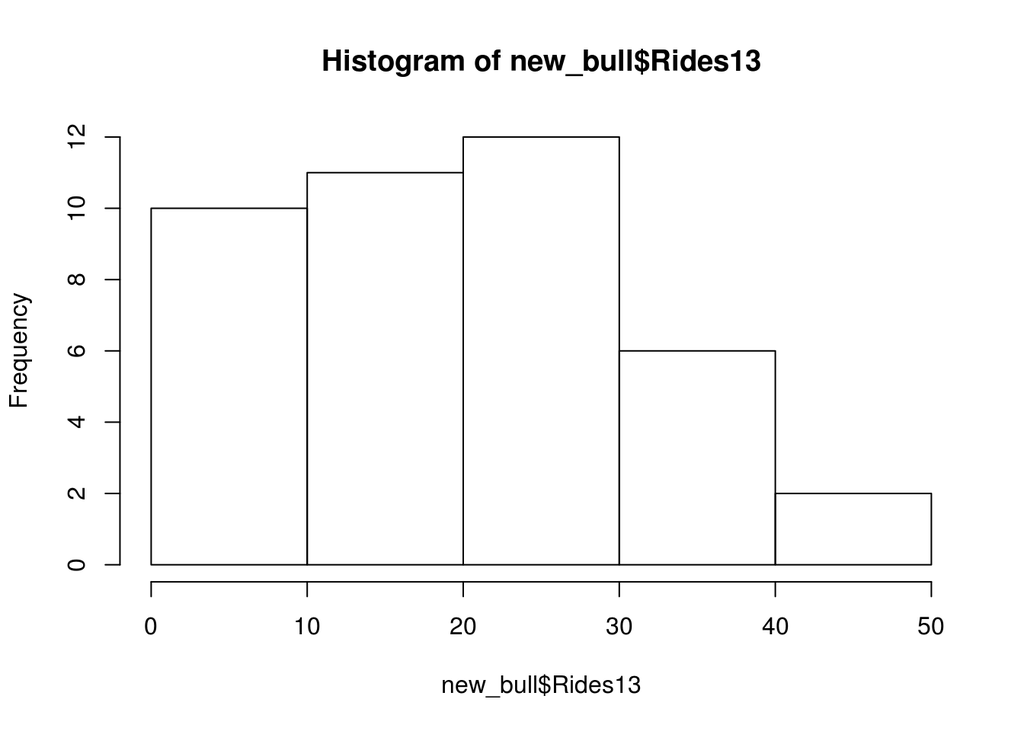

```r
#Subset for riders that participated in at least one event in 2013
new_bull <- bull[bull$Events13  > 0 ,]

# Visualize and describe the first variable of interest
hist(new_bull$Rides13)
```

```r
fivenum(new_bull$Rides13)
```

```
## [1]  0 11 19 25 50
```

```r
mean(new_bull$Rides13)
```

```
## [1] 18.73171
```

```r
sd(new_bull$Rides13)
```

```
## [1] 12.7319
```

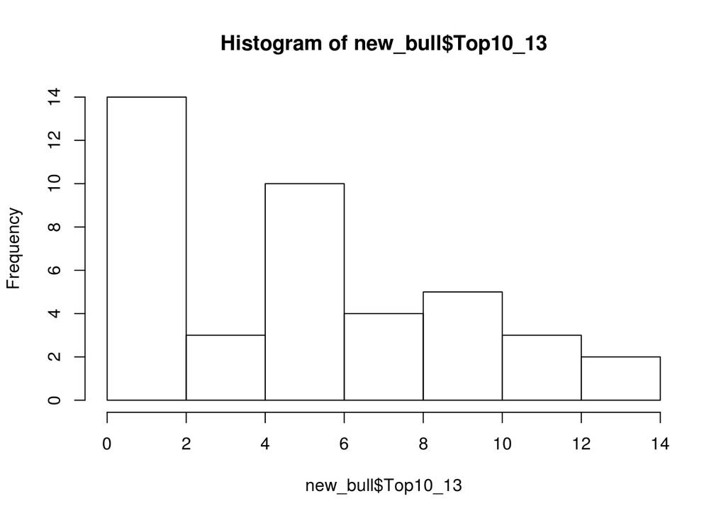

```r
# Visualize and describe the second variable of interest
hist(new_bull$Top10_13)
```

```r
fivenum(new_bull$Top10_13)
```

```
## [1]  0  2  6  8 14
```

```r
mean(new_bull$Top10_13)
```

```
## [1] 5.390244
```

```r
sd(new_bull$Top10_13)
```

```
## [1] 4.036571
```

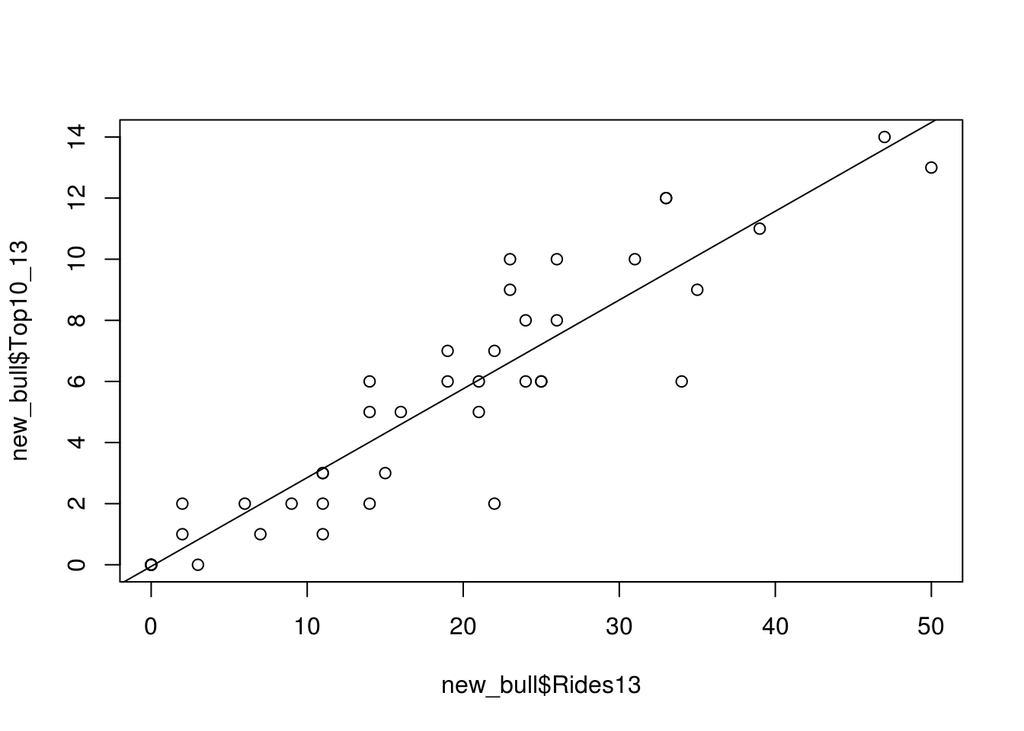

```r
# Create a scatterplot
plot(new_bull$Rides13,new_bull$Top10_13)

# Add line of best fit
abline(lm(new_bull$Top10_13~new_bull$Rides13))
```

```r
# Calculate the correlation coefficient
cor(new_bull$Rides13,new_bull$Top10_13)
```

```
## [1] 0.916606
```

```r
# Create a correlation matrix
vars <- c("Top10_13", "Rides13")
cor(new_bull[,vars])
```

```
##          Top10_13  Rides13
## Top10_13 1.000000 0.916606
## Rides13  0.916606 1.000000
```

problem 1/1 point (graded) 1. Which cases will be selected by this line of code? `new_bull <- bull[bull$Events13 > 0 ,]`

riders that have completed zero Events in 2013 riders that have completed at least zero Events in 2013 riders that have completed more than zero Events in 2013 correct Submit You have used 1 of 1 attempt Some problems have options such as save, reset, hints, or show answer. These options follow the Submit button.

Show Answer Correct (1/1 point) Review problem 1/1 point (graded) 2. What will appear in the scatterplot produced by this line of code? `plot(new_bull$Rides13,new_bull$Top10_13)`

There will be a single data point for each bull rider. correct There will be two data points for each rider (one for each variable). Submit You have used 1 of 1 attempt Some problems have options such as save, reset, hints, or show answer. These options follow the Submit button.

Show Answer Correct (1/1 point) Review problem 1/1 point (graded) 3. Which value is not a possible output of the following line of code?

`cor(new_bull$Rides13,new_bull$Top10_13)`

0.75 -1.02 correct 0.61 -0.04 Submit You have used 1 of 1 attempt Some problems have options such as save, reset, hints, or show answer. These options follow the Submit button.

Show Answer Correct (1/1 point) Review problem 1/1 point (graded) 4. A correlation matrix allows you to calculate multiple correlation coefficients at a time. Here, we are only asking for the correlation between Rides13 and Top10_13. If you wanted to include other variables as well, how would you do that?

`# Create a correlation matrix` `vars <-c("Top10_13", "Rides13")` `cor(new_bull[,vars])`

Eliminate the line cor(new_bull[,vars]), because a correlation is only between two variables. Add the variable names to the “vars” object. correct You couldn’t do that. You would have to run separate correlation matrices for each pair of variables. Submit You have used 1 of 1 attempt Some problems have options such as save, reset, hints, or show answer. These options follow the Submit button.

Show Answer Correct (1/1 point) Review The following plot was produced using the code listed below:

```
bull<-BullRiders
plot(bull$Events12, bull$BuckOuts12)
abline(lm(bull$Events12~bull$BuckOuts12))
```

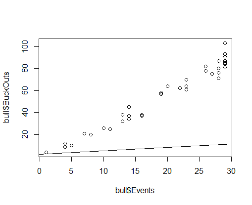

Scatter Plot

problem 1/1 point (graded) 5. In the above scatterplot, why does the line of best fit seem to not be going through the center of the scatterpot? (Refer to the code below and the dataset in R for help.)

The “Events” and “BuckOuts” variables should be switched in the abline command. correct The “O”should not be capitalized in “BuckOuts”. The plot was created with two variables that are categorical. The line of best fit goes through the plot accurately.

Primary Research Question

For the 2013 season, is there a linear relationship between how often a rider placed in the Top 10 and the number of times he stayed on his bull for a full 8 seconds?

Conduct the Analysis in R

1. Type or copy the script from the the Prepare for the Analysis section into the Script window of R.
2. Select the portion of the code you wish to run, then press “ctrl+ enter.”
3. Output can be found in the Console window.

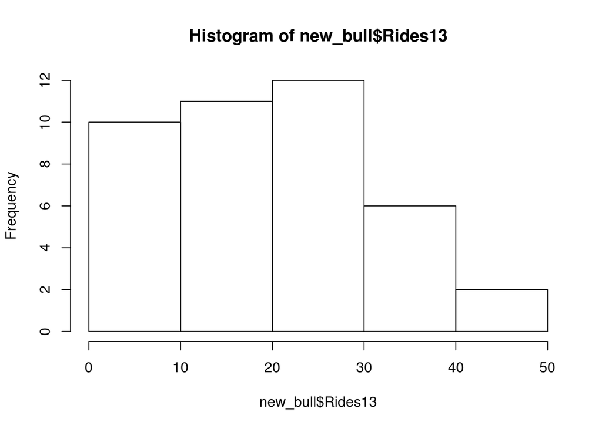

```r
#Subset for riders that participated in at least one event in 2013
new_bull <- bull[bull$Events13  > 0 ,]

# Visualize and describe the first variable of interest
hist(new_bull$Rides13)
```

```r
fivenum(new_bull$Rides13)
```

```
## [1]  0 11 19 25 50
```

```r
mean(new_bull$Rides13)
```

```
## [1] 18.73171
```

```r
sd(new_bull$Rides13)
```

```
## [1] 12.7319
```

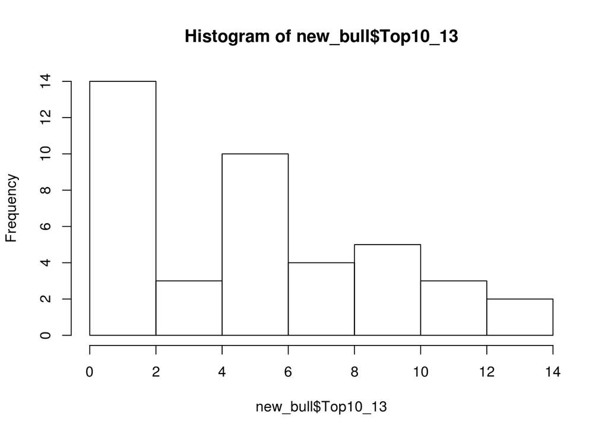

```r
# Visualize and describe the second variable of interest
hist(new_bull$Top10_13)
```

```r
fivenum(new_bull$Top10_13)
```

```
## [1]  0  2  6  8 14
```

```r
mean(new_bull$Top10_13)
```

```
## [1] 5.390244
```

```r
sd(new_bull$Top10_13)
```

```
## [1] 4.036571
```

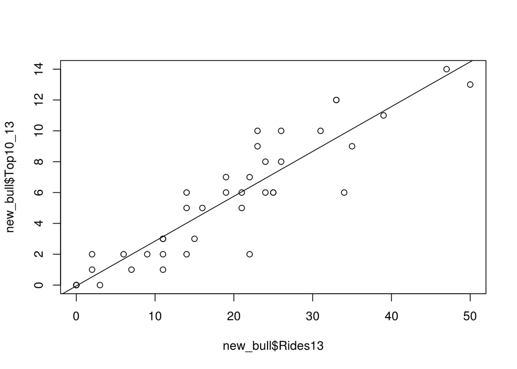

```r
# Create a scatterplot
plot(new_bull$Rides13,new_bull$Top10_13)

# Add line of best fit
abline(lm(new_bull$Top10_13~new_bull$Rides13))
```

```r
# Calculate the correlation coefficient
cor(new_bull$Rides13,new_bull$Top10_13)
```

```
## [1] 0.916606
```

```r
# Create a correlation matrix
vars <- c("Top10_13", "Rides13")
cor(new_bull[,vars])
```

```
##          Top10_13  Rides13
## Top10_13 1.000000 0.916606
## Rides13  0.916606 1.000000
```

```r
which(new_bull$Top10_13==2 & new_bull$Rides13==22)
```

```
## [1] 4
```

```r
new_bull[4,]
```

```
##            Rider Rank15 Country YearBorn Height Weight YearsPro Events14
## 5 Nathan Schaper      5     USA     1990     73    160        6       15
##   BuckOuts14 Rides14 CupPoints14 Rank14 RidePer14 RidesPer_45bull_14
## 5         41      17     3240.25     31    0.4146                  0
##   Rides90pts_14 Wins14 Top5_14 Top10_14 FinalPoints14 Earnings14 Events13
## 5             0      1       1        3          83.5    77426.3       24
##   BuckOuts13 Rides13 CupPoints13 Rank13 RidePer13 RidesPer_45bull_13
## 5         66      22     4304.41     25    0.3333                  0
##   Rides90pts_13 Wins13 Top5_13 Top10_13 FinalPoints13 Earnings13 Events12
## 5             0      0       2        2             0   58577.22        0
##   BuckOuts12 Rides12 CupPoints12 Rank12 RidePer12 Wins12 Top5_12 Top10_12
## 5          0       0           0      0         0      0       0        0
##   FinalPoints12 Earnings12
## 5             0          0
```

problem 2/2 points (graded) What do the histogram and descriptive statistics tell us about the distribution of the Rides13 variable?

1a. On average, a bull rider in 2013 has how many rides? (Report the median becuase the histogram is not symmetrical.)

19 correct 19 1b. These bull riders made it into the Top 10 an average of ________ times in 2013. (Hint: Remember again that the histogram is not symmetrical.)

6 correct 6

problem 4/4 points (graded) What does the scatterplot show us?

2a. The relationship looks ________, ________, and ________.

correct correct correct 2b. It looks like bull riders that appear frequently in the Top 10 list tend to have a ________ number of successful rides.

correct

problem 2/2 points (graded) 3a. The correlation, rounded to three decimal places, between the number of Top 10 appearances and the number of successful rides for 2013 is r =

0.917 correct 0.917 3b. How many times does this value appear in the correlation matrix? (Report as a numeral)

2 correct 2

problem 2/2 points (graded) 4. On the scatterplot, we see a data point with a fairly large residual. This rider had 22 rides, but he only placed in the Top 10 two times. This rider’s data point falls ________ the line of best fit. If his data followed the line of best fit, he should have placed in the Top 10 about ________ times.

correct correct

problem 2/2 points (graded) 4. On the scatterplot, we see a data point with a fairly large residual. This rider had 22 rides, but he only placed in the Top 10 two times. This rider’s data point falls ________ the line of best fit. If his data followed the line of best fit, he should have placed in the Top 10 about ________ times.

correct correct

Show Answer Correct (2/2 points) Review problem 1/1 point (graded) Use this code to help identify this rider: `#identify a specific record` `which(new_bull$Top10_13==2 & new_bull$Rides13==22)`

5. After looking at the data for this rider, can you explain why he has placed in the Top 10 so few times?

He weighs more than 200 pounds, so he is too heavy. He had only 12 rides, so he was not able to be competitive for the Top 10. He did not participate in any events during the 2013 season. His ride percentage was only about 33%, which wasn’t high enough to place him in the Top 10. correct

problem 4/4 points (graded) Write Your Conclusion

Answer the question and support your answer with statistics:

There is a strong correct linear relationship between the number of 8-second rides a bull rider completed and the total number of times he made it in the Top 10 after the 2013 season, (r = correct ). The average number of rides for these bull riders was around correct .There were no significant outliers. One rider appeared to have placed in the top-10 rankings only twice, despite an above-average number of rides. Upon closer inspection, we could see that he did not have a very high correct which might account for his few appearances in the Top 10.

Lab

problem 2/2 points (graded) Review of Correlation

In this lab, you will use correlation to answer a question of interest. Let’s start by remembering why we use correlation.

1a. A correlation can tell us:

how much one variable causes another to vary. the direction and strength of a linear relationship between two quantitative variables. correct the frequency of scores for a quantitative variable. the number of data points in a scatterplot that are outliers.

1b. Look at the scatterplot below. Select the answer that best describes what would happen to the value of the correlation coefficient rxy if the circled point were removed from the analysis.

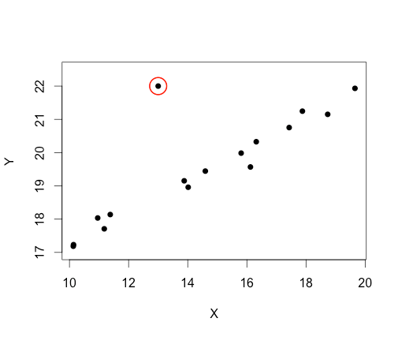

The value of rxy would increase. correct Removing the outlier would have no effect on the correlation coefficient. The value of rxy would decrease. The circled point is not an outlier. It fits with the trend of the data.

problem 1/1 point (graded) Lab Preparation

In this lab you will be working with data from the Professional Bull Riders Association.

1. Open RStudio. Make sure you’ve installed the current version of the SDSFoundations package.
2. Type library(SDSFoundations) This will automatically load the data for the labs. 3.Type bull <- BullRiders This will assign the data to your Workspace.

Alternatively, you can use follow the steps in the “Importing a Data Frame” R tutorial video, and use the BullRiders.csv file. (Right-click and “Save As.”) Make sure to name the dataframe “bull” when importing.

1. Open RStudio.
2. Click on “Import Dataset” button at the top of the workspace window. Choose “from text file.”
3. Click on the location of the BullRiders.csv file you just downloaded.
4. Click on the BullRiders.csv file. Then, click Upload.
5. Look at the spreadsheet view of the data to answer the following questions.
6. One of the following questions will be answered in this lab using correlation. Select the question that can be answered with correlation.

Is there a difference between the earnings of professional and non-professional bull riders? Is there a relationship between the name of the bull and the number of times he has bucked a rider? Which variable has the strongest linear relationship with earnings: successful ride percentage or Cup points? correct On average, how much does a professional bull rider earn each year?

Primary Research Question

In 2012, which variable had the strongest linear relationship with Earnings: Ride Percentage or Cup Points?

Analysis

Let’s break this analysis into the different steps that you will need to take to construct a complete answer. Be sure to:

1. Create a dataset which contains riders that participated in at least one event in 2012. Call the dataset new_bull12.
2. Make a histogram to visualize the distribution of Earnings for 2012.
3. Generate the appropriate descriptive statistics for this distribution.
4. Make a correlation matrix for Earnings12, RidePer12 and CupPoints12.
5. Plot a scatterplot for Earnings12 with each variable of interest. Put Earnings12 on the y-axis. Check for outliers.
6. Determine which variable has the strongest linear relationship with Earnings12.

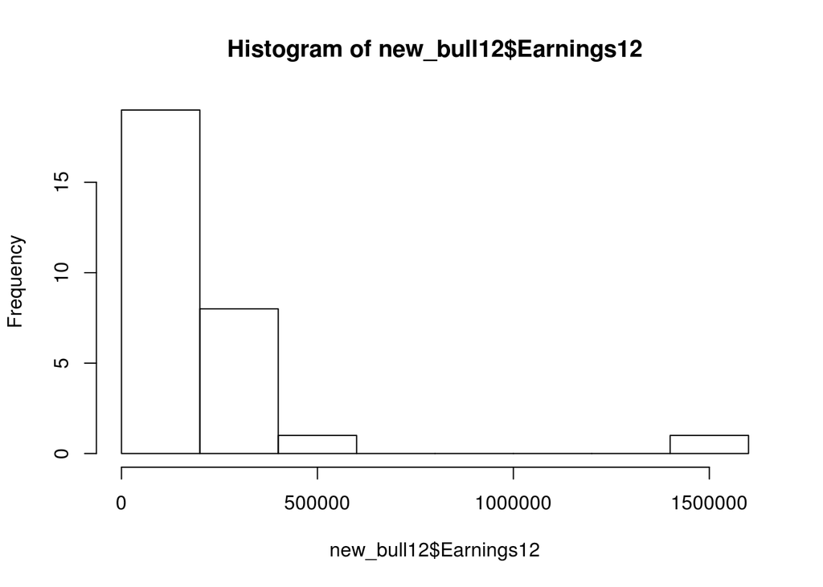

```r
new_bull12 <- bull[bull$Events12 > 0, ]
hist(new_bull12$Earnings12)
```

```r
fivenum(new_bull12$Earnings12)
```

```
## [1]   21343.28   66814.33  147952.34  239935.66 1464475.61
```

```r
cor(new_bull12[, c("Earnings12", "RidePer12", "CupPoints12")])
```

```
##             Earnings12 RidePer12 CupPoints12
## Earnings12   1.0000000 0.5934110   0.6569363
## RidePer12    0.5934110 1.0000000   0.9183375
## CupPoints12  0.6569363 0.9183375   1.0000000
```

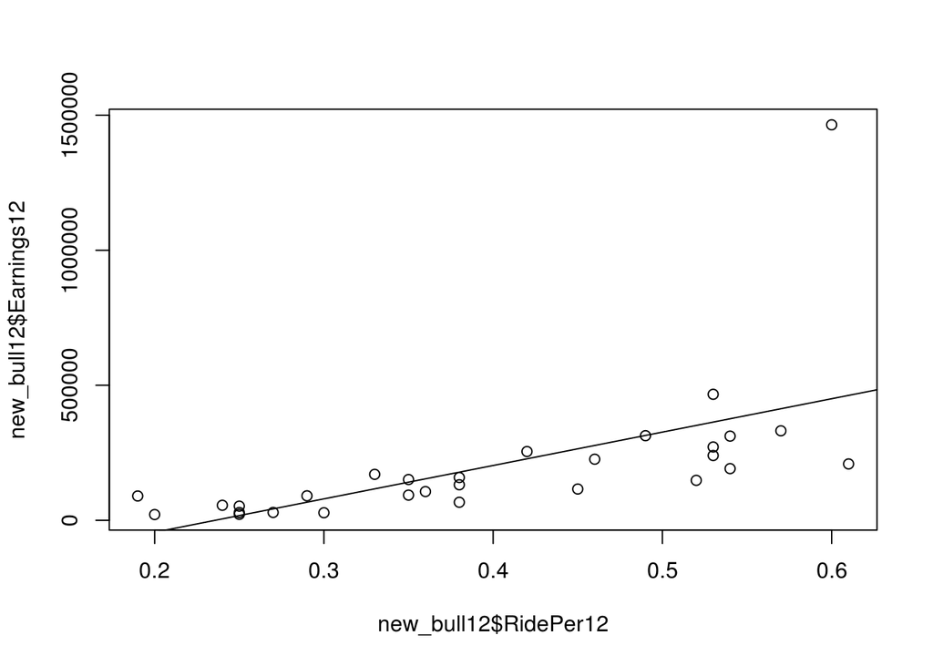

```r
plot(new_bull12$RidePer12, new_bull12$Earnings12)
abline(lm(new_bull12$Earnings12 ~ new_bull12$RidePer12))
```

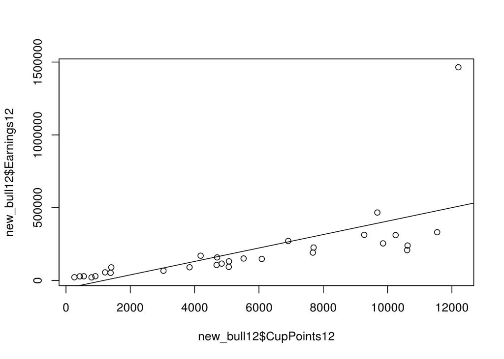

```r
plot(new_bull12$CupPoints12, new_bull12$Earnings12)
abline(lm(new_bull12$Earnings12 ~ new_bull12$CupPoints12))
```

problem 3/3 points (graded) Earnings Distribution

1a. What is the shape of the Earnings distribution for 2012?

positively skewed correct negatively skewed 1b. What was the average amount earned by a bull rider? (Choose the appropriate measure of center; report without a $ sign and round to the nearest whole number.)

147952 correct 147952 1c. What was the highest amount earned by a bull rider? (Report without a $ sign and round to the nearest whole number.)

1464476 correct 1464476

problem 2/2 points (graded) Make a Scatterplot of Earnings and Ride Percentage

2a. Does the scatterplot show a linear relationship?

correct 2b. What is the correlation of Earnings with Ride Percentage for 2012? (round to three decimal places)

0.593 correct 0.593

problem 2/2 points (graded) Create a Scatterplot of Earnings and Cup Points

3a. Does the scatterplot show a linear relationship?

correct 3b. What is the correlation of Earnings with Cup Points for 2012? (report to three decimal places)

0.657 correct 0.657

```r
# identify specific case
which(new_bull12$Earnings12 == max(new_bull12$Earnings12))
```

```
## [1] 4
```

```r
new_bull12[4,]
```

```
##           Rider Rank15 Country YearBorn Height Weight YearsPro Events14
## 8 Silvano Alves      8     BRA     1987     67    150        7       28
##   BuckOuts14 Rides14 CupPoints14 Rank14 RidePer14 RidesPer_45bull_14
## 8         92      50     9004.06      1    0.5435             0.3333
##   Rides90pts_14 Wins14 Top5_14 Top10_14 FinalPoints14 Earnings14 Events13
## 8             1      0       7       12          3607    1422603       27
##   BuckOuts13 Rides13 CupPoints13 Rank13 RidePer13 RidesPer_45bull_13
## 8         91      50    10937.75      2    0.5495                0.2
##   Rides90pts_13 Wins13 Top5_13 Top10_13 FinalPoints13 Earnings13 Events12
## 8             3      3      11       13          3780   625650.8       29
##   BuckOuts12 Rides12 CupPoints12 Rank12 RidePer12 Wins12 Top5_12 Top10_12
## 8        103      62    12201.75      1       0.6      2       8       18
##   FinalPoints12 Earnings12
## 8          1648    1464476
```

```r
#Subset the data
nooutlier <- new_bull12[new_bull12$Earnings12 < 1000000 ,]

cor(nooutlier[, c("Earnings12", "RidePer12", "CupPoints12")])
```

```
##             Earnings12 RidePer12 CupPoints12
## Earnings12   1.0000000 0.8035574   0.8929208
## RidePer12    0.8035574 1.0000000   0.9097881
## CupPoints12  0.8929208 0.9097881   1.0000000
```

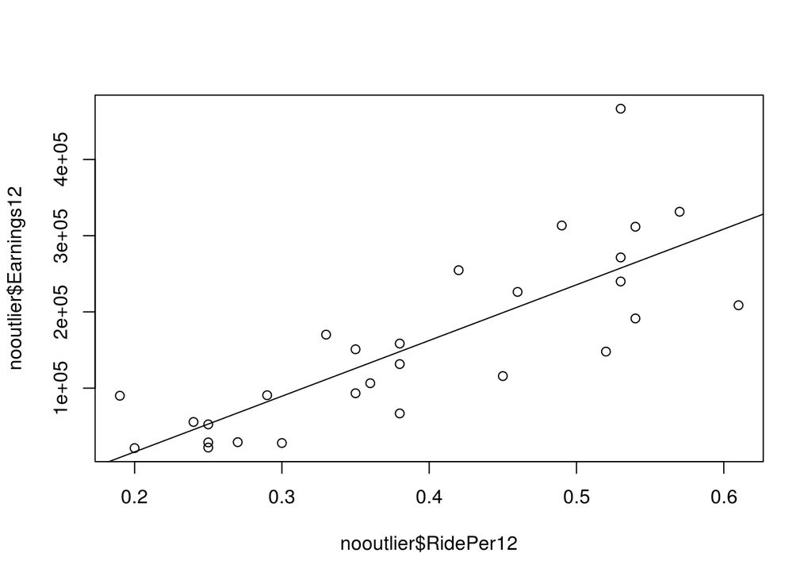

```r
plot(nooutlier$RidePer12, nooutlier$Earnings12)
abline(lm(nooutlier$Earnings12 ~ nooutlier$RidePer12))
```

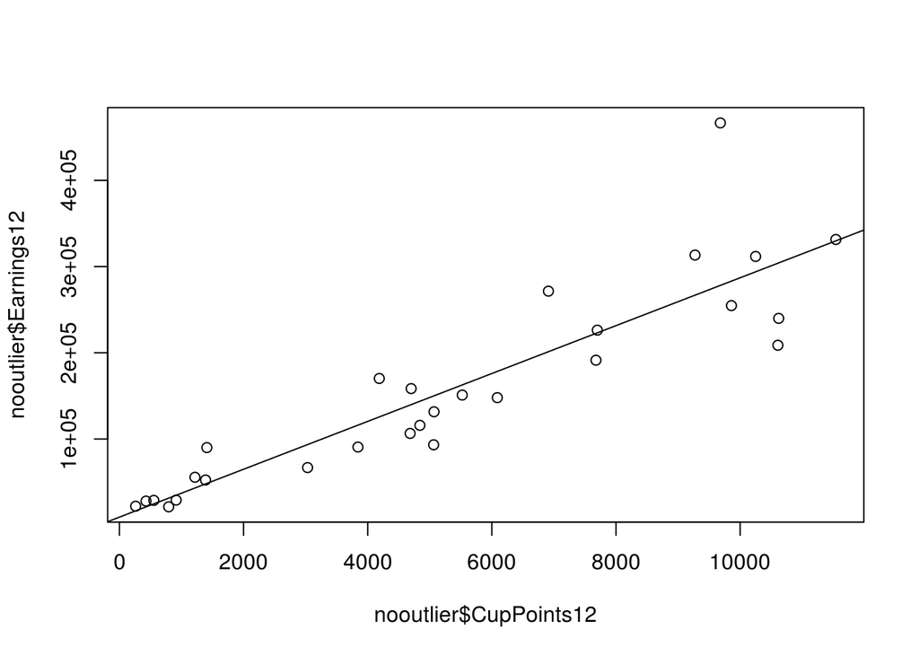

```r
plot(nooutlier$CupPoints12, nooutlier$Earnings12)
abline(lm(nooutlier$Earnings12 ~ nooutlier$CupPoints12))
```

problem 5/5 points (graded) Outliers and Influential Points

An outlier can have a significant impact on the correlation coefficient. Sometimes it is important to remove these points to examine the size of this impact. Run this code to identify the extreme data value in Earnings: `# identify specific case` `which(new_bull12$Earnings12 == max(new_bull12$Earnings12))`

4a. The extreme earnings data point belonged to the rider that came in ______ Place in 2012. (Please spell your answer; do not use numerals.)

First correct 4b. Where does this data point fall in the scatterplot? (Make sure that Earnings12 is on the y-axis)

Above the line correct Below the line On the line Let’s remove this data point from the dataset to assess what kind of impact, if any, it had on our correlation analysis. Run this code: `#Subset the data` `nooutlier <- new_bull12[new_bull12$Earnings12 < 1000000 ,]`

Then rerun the correlation matrix and the scatterplots to see the difference. Make sure to use the new dataframe (nooutlier) that you just created.

4c. After removing the outlier, what was the new correlation of Earnings and Ride Percentage for 2012? (Round to three decimals)

0.804 correct 0.804 4d. After removing the outlier, what was the new correlation of Earnings and Cup Points for 2012? (Round to three decimals)

0.893 correct 0.893 4e. We would say that this data point was an influential point because it

caused the underlying relationship to be non-linear. inflated the relationship between Earnings and the other variables. made the earnings of the other bull riders look less impressive than they really were. masked the strength of the relationships between Earnings and the other variables correct

Primary Research Question

In 2012, what variable had the strongest linear relationship with Earnings: Percentage rides or Cup points?

problem 8/8 points (graded) Write Your Conclusion

Answer the question and support your answer with statistics:

An initial examination of the relationships between Ride Percentage (RidePer) and Earnings, and Cup Points (CupPoints) and Earnings showed that Cup Points had the correct relationship to Earnings. Ride Percentage and Earnings showed a correlation value of correct while Cup Points and Earnings had a correlation value of correct . Visual examination showed an correct in both relationships—a rider who has earned over 1 million dollars. Removal of this increased the initial relationship: Ride Percentage and Earnings now had a correlation value of correct and Cup Points and Earnings had a correlation value of correct . correct still had the higher relationship to Earnings. Visual examination showed a correct for both Ride Percentage and Cup Points, indicating the correct use of the correlation coefficient.

Question 1

During a professional bull-riding event, riders usually attempt to ride a bull three or more times. This means that they can record a “ride” (successfully staying on the bull) multiple times in the same event.

Subset the dataset for riders that had at least 1 ride in the 2014 season. Call this dataset new_bull. Create a new variable or vector for the average number of rides per event for each bull rider in the new_bull dataset: `RidesPerEvent14 <- new_bull$Rides14/new_bull$Events14` Make a histogram of your “rides per event” variable and find the five-number summary for your “rides per event” variable.

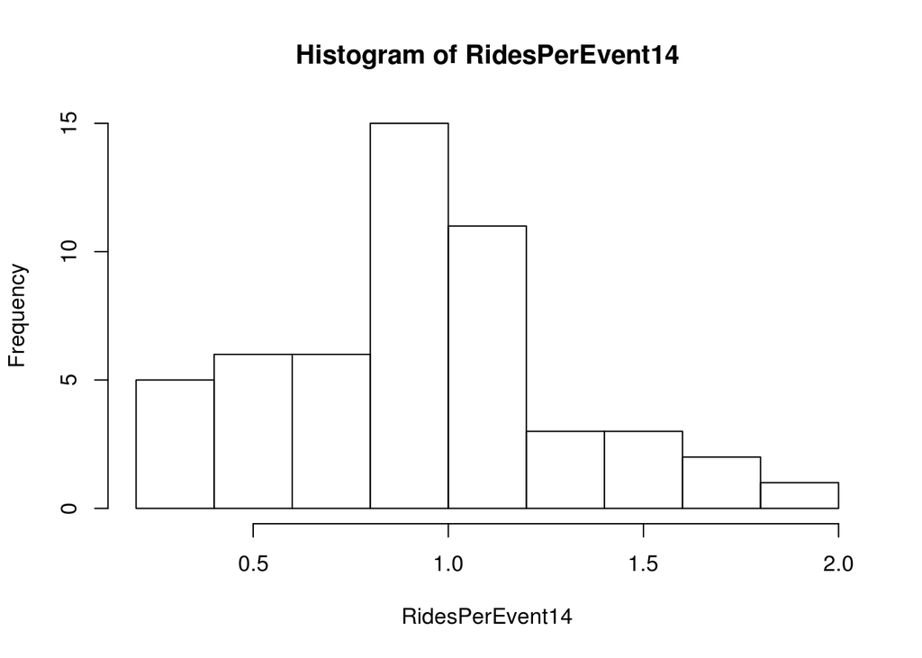

```r
newBull <-bull[bull$Rides14 > 0,]
RidesPerEvent14 <- newBull$Rides14 / newBull$Events14
hist(RidesPerEvent14)
```

```r
fivenum(RidesPerEvent14)
```

```
## [1] 0.2000000 0.6666667 1.0000000 1.1396104 2.0000000
```

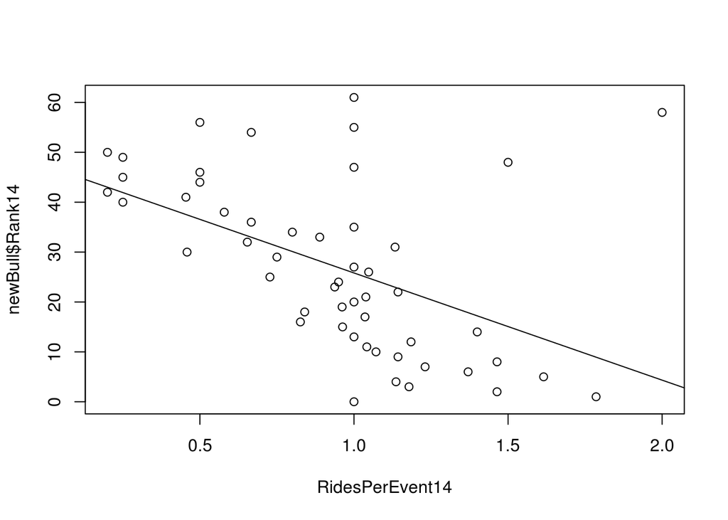

```r
plot(RidesPerEvent14, newBull$Rank14)
abline(lm(newBull$Rank14 ~ RidesPerEvent14))
```

```r
cor(RidesPerEvent14, newBull$Rank14)
```

```
## [1] -0.4945153
```

problem 5/5 points (graded) 1a. What is the minimum value? (Round to 2 decimal places.)

0.20 correct 0.20 1b. What is the median?

1.00 correct 1.00 1c. What is the maximum value? (Round to 2 decimal places.)

2.00 correct 2.00 1d. Create a scatterplot of “rides per event” and yearly ranking (defined by the “Rank14” variable) and add a line of best fit. Which of the following best describes the relationship between these two variables?

The two variables are related, but it’s not linear. The two variables have no discernable linear relationship. The two variables have a positive linear relationship. The two variables have a negative linear relationship. correct 1e. What is the correlation coefficient for rides per event and yearly ranking? (Report to 3 decimal places)

-0.495 correct −0.495

problem 0/1 point (graded) 1f. Suppose that college GPA and graduate school GPA have a correlation coefficient of 0.75. Based on this, what proportion of variation in graduate school GPA is left unexplained after taking college GPA into account? (Report to 4 decimal places)?

0.25 incorrect .4375

Below are six scatterplots, each with a specific relationship. Use these scatterplots to answer each of the following questions.

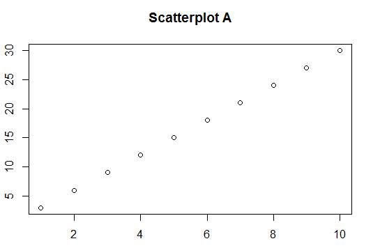

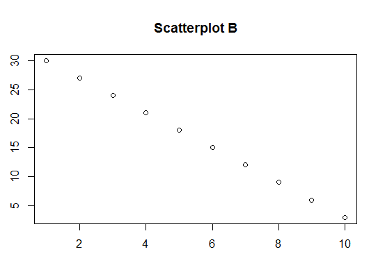

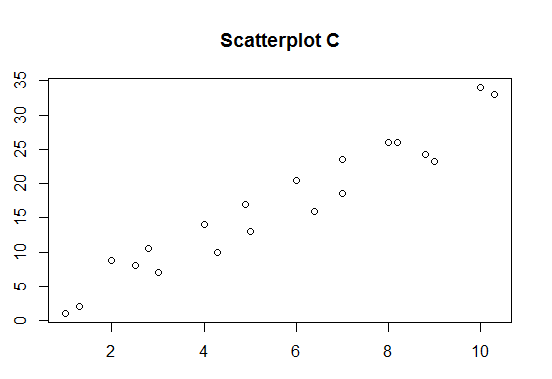

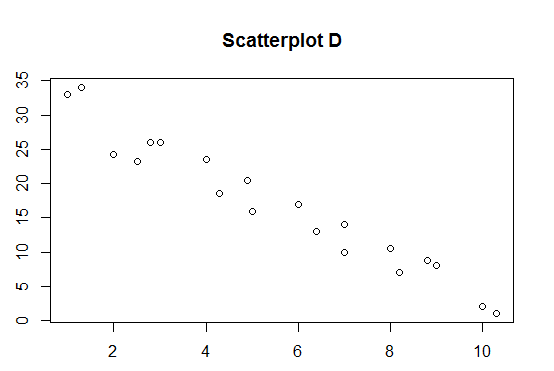

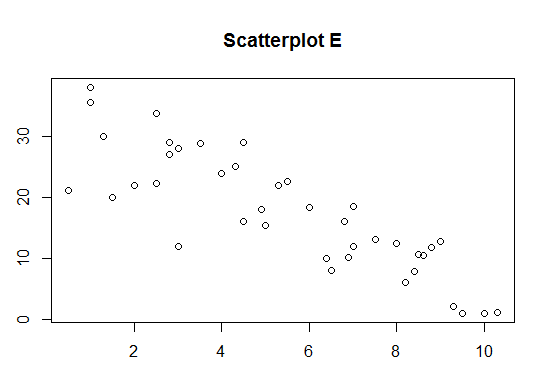

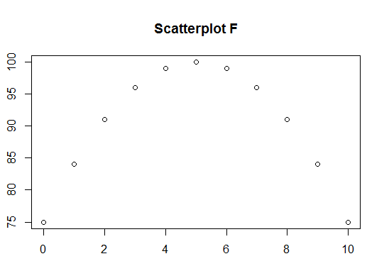

problem 4/6 points (graded) 1g. Choose the correct scatterplot for each correlation coefficient.

r = 1.0000

correctScatterplot A r = -0.790

incorrectScatterplot E r = 0.000

correctScatterplot F r = 0.950

correctScatterplot C 1h. Suppose you have been given a gift card worth $30. You wish to buy gloves that cost $3 per pair (including tax). Assuming that the price of gloves does not change, which scatterplot illustrates the relationship of the amount of money left on your gift card, given the number or pairs of gloves that you buy? correctScatterplot B 1i. Suppose we are exploring the relationship between time spent walking and calories burned. We ask a group of people to begin walking. When each person stops, we record the number of calories burned, along with how many minutes he or she walked. Which scatterplot would best fit this relationship between calories burned and time spent walking? incorrectScatterplot C

Question 2

Using the dataset below, find the correlation coefficient between time spent studying and exam grade.

Minutes Spent Studying Exam Grade 30 74 45 68 180 87 95 90 130 94 140 84 30 92 80 88 60 82 110 93 0 65 80 90 problem 2/6 points (graded) 2a. What is the correlation coefficient based on the data? (Round to 3 decimal places.)

0.597 correct.597 0.597 2b. Approximately what percentage of the variation in exam scores can be explained by the amount of time that each student studied? (Roune to whole number without a % sign.)

36 correct36 36 2c. Create a scatterplot of the data (exam grades and time spent studying). What is the value of the outlier (the student that got a high grade but didn’t study very long)?

X =

0 incorrect30 0 Y =

65 incorrect92 65 2d. When the outlier is removed, what is the new value of r? (Round to 3 decimal places.)

0.432 incorrect.737 0.432 2e. How did the outlier impact our efforts to assess the relationship between time spent studying and exam grades?

The outlier caused the relationship to look stronger than it really is. incorrect The outlier caused the relationship to look weaker than it really is. correct The outlier did not significantly effect the relationship.